# Logistic Regression Models for the VQI FBVAR Dataset

Jennifer Ci, Thu Vu, Lily Hanyi Wang

Variables to adjust for:

- cluster on `CENTERID`
- `AGECAT`, `GENDER`, `PREOP_SMOKING`, `PRIOR_AORSURG`, `PRIOR_CHF`
- `PATHOLOGY`, `extent`, `NUM_TREATED_BRANCHES`, `NUM_TREATED_RENALS`, `OCCLUDED_SMA`

Outcome variables:

- `POSTOP_CEREBROSX`, `POSTOP_SPINAL_ISCHEMIA`, `POSTOP_DIALYSIS`, `POSTOP_LOS`, `POSTOP_COMPLICATIONS`, `POSTOP_DIALYSIS`, `POSTOP_LEGEMBO`, `POSTOP_CEREBROSX`, `POSTOP_RESPIRATORY`, `POSTOP_SPINAL_ISCHEMIA`, `RETX_R_RTOR`, `BRANCH_POST`

# Logistic regression for categorical outcomes

## Stroke:

ARMNECK_ACCESS => POSTOP_CEREBROSX

`extent`, `PATHOLOGY`

Logistic regression for stroke

Dependent: POSTOP_CEREBROSX

No

Yes

OR (univariable)

OR (multivariable)

29

PRESENTATION

Asymptomatic

2868 (98.7)

38 (1.3)

30

Symptomatic

378 (97.4)

10 (2.6)

2.00 (0.93-3.89, p=0.054)

1.21 (0.49-2.71, p=0.667)

1

AGECAT

<50

39 (95.1)

2 (4.9)

2

>79

699 (98.6)

10 (1.4)

0.28 (0.07-1.85, p=0.107)

0.52 (0.09-4.63, p=0.509)

3

50-59

138 (96.5)

5 (3.5)

0.71 (0.15-5.06, p=0.685)

0.49 (0.07-4.36, p=0.479)

4

60-69

838 (99.8)

2 (0.2)

0.05 (0.01-0.40, p=0.002)

0.06 (0.01-0.66, p=0.016)

5

70-79

1532 (98.1)

29 (1.9)

0.37 (0.11-2.33, p=0.183)

0.50 (0.09-4.30, p=0.468)

14

GENDER

female

813 (97.6)

20 (2.4)

15

male

2433 (98.9)

28 (1.1)

0.47 (0.26-0.85, p=0.010)

0.57 (0.30-1.10, p=0.086)

27

PREOP_SMOKING

No

404 (97.8)

9 (2.2)

28

Yes

2842 (98.6)

39 (1.4)

0.62 (0.31-1.36, p=0.195)

1.15 (0.51-2.89, p=0.755)

31

PRIOR_AORSURG

Both

81 (97.6)

2 (2.4)

32

Endo

344 (98.6)

5 (1.4)

0.59 (0.12-4.16, p=0.531)

0.83 (0.16-6.38, p=0.840)

33

None

2524 (98.7)

34 (1.3)

0.55 (0.16-3.40, p=0.411)

1.23 (0.31-8.44, p=0.798)

34

Open

297 (97.7)

7 (2.3)

0.95 (0.23-6.49, p=0.954)

0.91 (0.18-6.82, p=0.913)

35

PRIOR_CHF

No

2815 (98.6)

39 (1.4)

36

Yes

431 (98.0)

9 (2.0)

1.51 (0.68-2.99, p=0.272)

1.97 (0.85-4.14, p=0.090)

23

PATHOLOGY

Aneurysm

3046 (98.9)

35 (1.1)

24

Aneurysm from dissection

100 (90.1)

11 (9.9)

9.57 (4.52-18.82, p<0.001)

6.40 (2.33-16.92, p<0.001)

25

Dissection

67 (97.1)

2 (2.9)

2.60 (0.42-8.76, p=0.195)

1.74 (0.20-9.64, p=0.566)

26

PAU/IMH

33 (100.0)

0 (0.0)

0.00 (0.00-248892879.96, p=0.985)

0.00 (0.00-6698810.37, p=0.985)

8

extent

Juxtarenal AAA

1276 (99.1)

12 (0.9)

9

Type 1 TAAA

8 (100.0)

0 (0.0)

0.00 (NA-65873745081875888426975232.00, p=0.989)

0.00 (NA-1516877094032561657310064300509051865792512.00, p=0.991)

10

Type 2 TAAA

180 (93.8)

12 (6.2)

7.09 (3.11-16.18, p<0.001)

2.08 (0.62-6.83, p=0.231)

11

Type 3 TAAA

563 (98.4)

9 (1.6)

1.70 (0.69-4.04, p=0.232)

0.92 (0.30-2.69, p=0.879)

12

Type 4 TAAA

960 (98.6)

14 (1.4)

1.55 (0.71-3.43, p=0.268)

1.24 (0.52-3.00, p=0.632)

13

Type 5 TAAA

53 (98.1)

1 (1.9)

2.01 (0.11-10.47, p=0.507)

0.54 (0.03-3.67, p=0.593)

16

NUM_TREATED_BRANCHES

1

395 (98.3)

7 (1.7)

17

2

725 (97.3)

20 (2.7)

1.56 (0.68-4.00, p=0.318)

3.21 (1.13-9.90, p=0.033)

18

3

986 (99.2)

8 (0.8)

0.46 (0.16-1.31, p=0.134)

1.88 (0.41-9.06, p=0.422)

19

4

1140 (98.9)

13 (1.1)

0.64 (0.26-1.72, p=0.351)

1.19 (0.23-6.34, p=0.838)

20

NUM_TREATED_RENALS

0

461 (96.0)

19 (4.0)

21

1

133 (98.5)

2 (1.5)

0.36 (0.06-1.28, p=0.179)

0.35 (0.05-1.44, p=0.202)

22

2

2652 (99.0)

27 (1.0)

0.25 (0.14-0.45, p<0.001)

0.30 (0.09-0.99, p=0.050)

6

ARMNECK_ACCESS

No

2357 (99.2)

20 (0.8)

7

Yes

889 (96.9)

28 (3.1)

3.71 (2.09-6.71, p<0.001)

2.76 (1.37-5.62, p=0.005)

| Number in dataframe = 3295, Number in model = 3088, Missing = 207, AIC = 455.1, C-statistic = 0.788, H&L = Chi-sq(8) 10.34 (p=0.242) |
| --- |

[figure not shown]

## Spinal cord model:

POSTOP_SPINALDRAIN and OCCLUDED_CELIAC => POSTOP_SPINAL_ISCHEMIA

Logistic regression for spinal cord ischemia

Dependent: POSTOP_SPINAL_ISCHEMIA

No

Yes

OR (univariable)

OR (multivariable)

28

PRESENTATION

Asymptomatic

2823 (97.1)

84 (2.9)

29

Symptomatic

363 (93.6)

25 (6.4)

2.31 (1.43-3.61, p<0.001)

1.34 (0.73-2.35, p=0.323)

1

AGECAT

<50

40 (97.6)

1 (2.4)

2

>79

690 (97.3)

19 (2.7)

1.10 (0.22-20.04, p=0.926)

1.47 (0.23-29.30, p=0.731)

3

50-59

137 (95.8)

6 (4.2)

1.75 (0.29-33.60, p=0.609)

1.28 (0.17-26.52, p=0.835)

4

60-69

821 (97.7)

19 (2.3)

0.93 (0.18-16.84, p=0.941)

0.76 (0.12-15.00, p=0.808)

5

70-79

1498 (95.9)

64 (4.1)

1.71 (0.36-30.55, p=0.599)

1.45 (0.24-28.18, p=0.736)

12

GENDER

female

794 (95.3)

39 (4.7)

13

male

2392 (97.2)

70 (2.8)

0.60 (0.40-0.90, p=0.011)

0.95 (0.60-1.53, p=0.830)

26

PREOP_SMOKING

No

407 (98.5)

6 (1.5)

27

Yes

2779 (96.4)

103 (3.6)

2.51 (1.19-6.47, p=0.029)

2.97 (1.31-8.16, p=0.018)

30

PRIOR_AORSURG

Both

76 (91.6)

7 (8.4)

31

Endo

333 (95.4)

16 (4.6)

0.52 (0.21-1.40, p=0.167)

0.81 (0.30-2.44, p=0.689)

32

None

2490 (97.3)

69 (2.7)

0.30 (0.14-0.74, p=0.004)

1.19 (0.50-3.32, p=0.711)

33

Open

287 (94.4)

17 (5.6)

0.64 (0.27-1.71, p=0.345)

0.80 (0.30-2.37, p=0.668)

34

PRIOR_CHF

No

2756 (96.5)

99 (3.5)

35

Yes

430 (97.7)

10 (2.3)

0.65 (0.31-1.19, p=0.195)

0.69 (0.31-1.36, p=0.318)

20

PATHOLOGY

Aneurysm

2984 (96.8)

98 (3.2)

21

Aneurysm from dissection

106 (95.5)

5 (4.5)

1.44 (0.50-3.26, p=0.440)

0.54 (0.17-1.35, p=0.225)

22

Dissection

64 (92.8)

5 (7.2)

2.38 (0.82-5.49, p=0.068)

1.18 (0.34-3.53, p=0.781)

23

PAU/IMH

32 (97.0)

1 (3.0)

0.95 (0.05-4.49, p=0.961)

0.89 (0.05-5.28, p=0.914)

6

extent

Juxtarenal AAA

1270 (98.6)

18 (1.4)

7

Type 1 TAAA

7 (87.5)

1 (12.5)

10.08 (0.53-60.96, p=0.035)

1.95 (0.09-16.77, p=0.591)

8

Type 2 TAAA

172 (89.6)

20 (10.4)

8.20 (4.25-15.95, p<0.001)

1.52 (0.64-3.59, p=0.342)

9

Type 3 TAAA

534 (93.4)

38 (6.6)

5.02 (2.88-9.07, p<0.001)

0.94 (0.46-1.95, p=0.862)

10

Type 4 TAAA

949 (97.3)

26 (2.7)

1.93 (1.06-3.60, p=0.033)

0.97 (0.49-1.93, p=0.924)

11

Type 5 TAAA

53 (98.1)

1 (1.9)

1.33 (0.07-6.64, p=0.783)

0.22 (0.01-1.21, p=0.156)

14

NUM_TREATED_BRANCHES

1

389 (96.8)

13 (3.2)

15

2

726 (97.4)

19 (2.6)

0.78 (0.39-1.64, p=0.503)

0.94 (0.41-2.28, p=0.893)

16

3

972 (97.8)

22 (2.2)

0.68 (0.34-1.39, p=0.272)

0.65 (0.29-1.55, p=0.315)

17

4

1099 (95.2)

55 (4.8)

1.50 (0.84-2.89, p=0.198)

0.66 (0.31-1.50, p=0.293)

18

OCCLUDED_CELIAC

FALSE

3100 (96.9)

100 (3.1)

19

TRUE

86 (90.5)

9 (9.5)

3.24 (1.48-6.30, p=0.001)

1.43 (0.56-3.41, p=0.435)

24

POSTOP_SPINALDRAIN

No

2551 (99.1)

22 (0.9)

25

Yes

635 (88.0)

87 (12.0)

15.89 (10.06-26.17, p<0.001)

18.11 (9.85-34.50, p<0.001)

| Number in dataframe = 3295, Number in model = 3089, Missing = 206, AIC = 770.2, C-statistic = 0.838, H&L = Chi-sq(8) 14.13 (p=0.078) |
| --- |

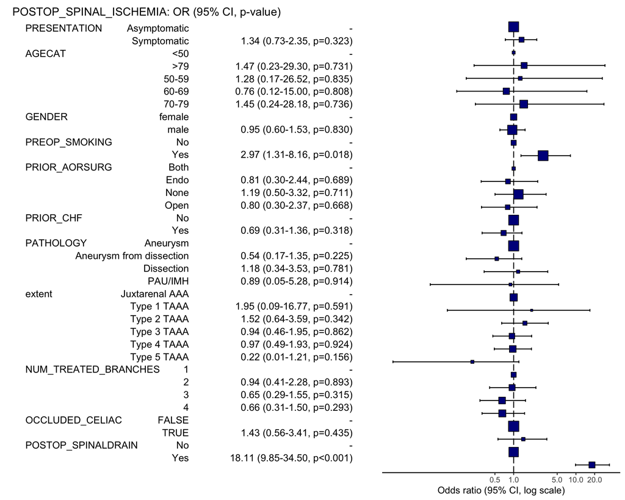

Odds ratio plot for spinal cord ischemia

## Dialysis model:

OCCLUDED_RENAL => POSTOP_DIALYSIS

`extent`, `AGECAT`

Logistic regression for dialysis

Dependent: POSTOP_DIALYSIS

No

Yes

OR (univariable)

OR (multivariable)

29

PRESENTATION

Asymptomatic

2820 (98.3)

49 (1.7)

30

Symptomatic

352 (95.1)

18 (4.9)

2.94 (1.65-5.02, p<0.001)

1.70 (0.86-3.20, p=0.114)

1

AGECAT

<50

38 (97.4)

1 (2.6)

2

>79

691 (98.3)

12 (1.7)

0.66 (0.12-12.18, p=0.693)

4630765.71 (0.00-76067921900323383958874372021301249535178239169071020629517561234034421576889963992577099161051807325557812350671363851949036132895735729905230129340975122660896232293644894208.00, p=0.989)

3

50-59

131 (94.9)

7 (5.1)

2.03 (0.35-38.57, p=0.514)

12757724.20 (0.00-12335308025307782885075034315311686122889499931898521612215891528348175276219557526642547620922020258294523234800379674006643384018200664835907536795207027079609204891426746269696.00, p=0.988)

4

60-69

806 (97.7)

19 (2.3)

0.90 (0.18-16.30, p=0.916)

5705254.94 (0.00-22446928687809331650998441387555905653244312889805100711272914108074110451246846899704803534800182707599969908240666349680096947131783591286468849026068910709024136751837347840.00, p=0.989)

5

70-79

1506 (98.2)

28 (1.8)

0.71 (0.14-12.76, p=0.736)

5234476.61 (0.00-NA, p=0.989)

12

GENDER

female

792 (96.7)

27 (3.3)

13

male

2380 (98.3)

40 (1.7)

0.49 (0.30-0.82, p=0.005)

0.60 (0.35-1.03, p=0.060)

27

PREOP_SMOKING

No

397 (98.3)

7 (1.7)

28

Yes

2775 (97.9)

60 (2.1)

1.23 (0.60-2.96, p=0.613)

1.27 (0.59-3.19, p=0.570)

31

PRIOR_AORSURG

Both

76 (96.2)

3 (3.8)

32

Endo

328 (97.3)

9 (2.7)

0.70 (0.20-3.19, p=0.592)

0.62 (0.16-3.02, p=0.501)

33

None

2475 (97.9)

52 (2.1)

0.53 (0.19-2.22, p=0.297)

0.65 (0.21-2.92, p=0.511)

34

Open

293 (99.0)

3 (1.0)

0.26 (0.05-1.43, p=0.103)

0.17 (0.02-1.12, p=0.065)

35

PRIOR_CHF

No

2753 (97.8)

62 (2.2)

36

Yes

419 (98.8)

5 (1.2)

0.53 (0.18-1.20, p=0.175)

0.42 (0.13-1.05, p=0.101)

23

PATHOLOGY

Aneurysm

2980 (98.0)

60 (2.0)

24

Aneurysm from dissection

104 (100.0)

0 (0.0)

0.00 (0.00-35169.01, p=0.982)

0.00 (0.00-878.74, p=0.980)

25

Dissection

58 (92.1)

5 (7.9)

4.28 (1.46-10.10, p=0.003)

2.10 (0.46-7.80, p=0.297)

26

PAU/IMH

30 (93.8)

2 (6.2)

3.31 (0.53-11.31, p=0.107)

3.53 (0.52-13.72, p=0.114)

6

extent

Juxtarenal AAA

1266 (98.5)

19 (1.5)

7

Type 1 TAAA

8 (100.0)

0 (0.0)

0.00 (NA-86019340466385.72, p=0.982)

0.00 (NA-413673451420563329969698432860753522660947045390964134495606727034011648.00, p=0.994)

8

Type 2 TAAA

172 (95.0)

9 (5.0)

3.49 (1.48-7.63, p=0.002)

2.52 (0.85-6.95, p=0.084)

9

Type 3 TAAA

543 (98.0)

11 (2.0)

1.35 (0.62-2.81, p=0.433)

1.29 (0.54-2.97, p=0.550)

10

Type 4 TAAA

930 (97.6)

23 (2.4)

1.65 (0.89-3.08, p=0.111)

1.53 (0.80-3.00, p=0.203)

11

Type 5 TAAA

50 (96.2)

2 (3.8)

2.67 (0.42-9.53, p=0.195)

1.93 (0.28-7.96, p=0.422)

14

NUM_TREATED_BRANCHES

1

372 (95.6)

17 (4.4)

15

2

706 (97.9)

15 (2.1)

0.46 (0.23-0.94, p=0.033)

0.79 (0.27-2.11, p=0.652)

16

3

974 (98.5)

15 (1.5)

0.34 (0.16-0.68, p=0.002)

0.76 (0.20-2.80, p=0.688)

17

4

1120 (98.2)

20 (1.8)

0.39 (0.20-0.76, p=0.005)

0.87 (0.21-3.42, p=0.840)

18

NUM_TREATED_RENALS

0

422 (95.3)

21 (4.7)

19

1

130 (96.3)

5 (3.7)

0.77 (0.25-1.94, p=0.612)

0.94 (0.27-2.87, p=0.912)

20

2

2620 (98.5)

41 (1.5)

0.31 (0.19-0.55, p<0.001)

0.50 (0.14-1.86, p=0.285)

21

OCCLUDED_RENAL

FALSE

3098 (98.1)

61 (1.9)

22

TRUE

74 (92.5)

6 (7.5)

4.12 (1.55-9.11, p=0.001)

1.94 (0.59-5.85, p=0.253)

| Number in dataframe = 3295, Number in model = 3033, Missing = 262, AIC = 613.8, C-statistic = 0.753, H&L = Chi-sq(8) 6.60 (p=0.580) |
| --- |

[figure not shown]

## Code Appendix

```r
knitr::opts_chunk$set(echo = FALSE,message = FALSE,warning = FALSE)
library(tidyverse)
library(table1)
library(survival)
library(Hmisc)
library(ggplot2)
library(ggpubr)
library(corrplot)
library(caret)
library(survminer)
library(knitr)
library(kableExtra)
library(finalfit)
library(broom)

## ------------- working directories for Lily ----------
wd_lily = '/Users/hanyiwang/Desktop/Comparative-analysis-of-treatments-of-CAA'
path_lily = c("../data/FBVAR.csv")


## ------------- working directories for Jenn ----------
# wd_jenn =
# path_jenn =

## ------------- working directories for Thu ----------
wd_thu = '/Users/thuvu/Desktop/Comparative-analysis-of-treatments-of-CAA'
path_thu = c("FBVAR.csv")

## ------------- read data ----------
setwd(wd_lily)
FBVAR = read.csv(path_lily)

# setwd(wd_jenn)
# FBVAR = read.csv(path_jenn)

# setwd(wd_thu)
# FBVAR = read.csv(path_thu)

## ------------- modify variables class----------

names <- c('PRESENTATION','POSTOP_LOS', 'POSTOP_COMPLICATIONS', 'POSTOP_DIALYSIS', 'POSTOP_LEGEMBO', 'POSTOP_CEREBROSX', 'POSTOP_RESPIRATORY', 'POSTOP_SPINAL_ISCHEMIA', 'RETX_R_RTOR', 'BRANCH_POST','AGECAT', 'GENDER', 'PREOP_SMOKING', 'PRIOR_AORSURG', 'PRIOR_CHF', 'PATHOLOGY', 'extent', 'NUM_TREATED_BRANCHES', 'NUM_TREATED_RENALS','OCCLUDED_RENAL', 'OCCLUDED_SMA', 'OCCLUDED_CELIAC','ARMNECK_ACCESS','CENTERID')
FBVAR[,names] <- lapply(FBVAR[,names] , factor)


## ------------- stroke ----------

## ------------- glm ----------

# lr_stroke = glm(POSTOP_CEREBROSX ~ PRESENTATION+ AGECAT + GENDER + PREOP_SMOKING+ PRIOR_AORSURG + PRIOR_CHF + PATHOLOGY + extent+NUM_TREATED_BRANCHES+ NUM_TREATED_RENALS+ OCCLUDED_RENAL+OCCLUDED_SMA+OCCLUDED_CELIAC+ARMNECK_ACCESS,
#     data = FBVAR, family = binomial)
#
# table2_stroke = lr_stroke %>% tidy(conf.int = TRUE, exp = TRUE)
# knitr::kable(table2_stroke,caption = 'Logistic regression for stroke')
#
# table2_stroke = lr_stroke %>% summary %>% coef %>% round(3) %>%
#   as_tibble(rownames="Coefficient") %>% select(1,2,3,5)
# knitr::kable(table2_stroke,caption = 'Logistic regression for stroke')
#
# test %>% glance() %>% as_tibble() %>% knitr::kable()

## ------------- finalfit with PATHOLOGY and extent ----------
explanatory = c('PRESENTATION','AGECAT', 'GENDER', 'PREOP_SMOKING','PRIOR_AORSURG', 'PRIOR_CHF','PATHOLOGY' ,'extent', 'NUM_TREATED_BRANCHES','NUM_TREATED_RENALS','ARMNECK_ACCESS')

table2_stroke = FBVAR %>% finalfit(
  dependent = 'POSTOP_CEREBROSX',
  explanatory =  explanatory ,
  metrics = TRUE)

knitr::kable(table2_stroke[[1]],caption = 'Logistic regression for stroke')
knitr::kable(table2_stroke[[2]])

## ------------- OR plot ----------
FBVAR %>% or_plot(
  dependent = 'POSTOP_CEREBROSX',
  explanatory =  explanatory,
  breaks = c(0.5, 1, 5, 10, 20))


## ------------- spinal cord ischemia  ----------

## ------------- finalfit ----------
explanatory = c('PRESENTATION','AGECAT', 'GENDER', 'PREOP_SMOKING','PRIOR_AORSURG', 'PRIOR_CHF','PATHOLOGY' ,'extent', 'NUM_TREATED_BRANCHES', 'OCCLUDED_CELIAC','POSTOP_SPINALDRAIN')

table2_SCI = FBVAR %>% finalfit(
  dependent = 'POSTOP_SPINAL_ISCHEMIA',
  explanatory =  explanatory ,
  metrics = TRUE)

knitr::kable(table2_SCI[[1]],caption = 'Logistic regression for spinal cord ischemia')
knitr::kable(table2_SCI[[2]])

## ------------- OR plot ----------

FBVAR %>% or_plot(
  dependent = 'POSTOP_SPINAL_ISCHEMIA',
  explanatory =  explanatory,
  breaks = c(0.5, 1, 5, 10, 20))


## ------------- dialysis  ----------

## ------------- finalfit ----------
explanatory = c('PRESENTATION','AGECAT', 'GENDER', 'PREOP_SMOKING','PRIOR_AORSURG', 'PRIOR_CHF','PATHOLOGY' ,'extent', 'NUM_TREATED_BRANCHES','NUM_TREATED_RENALS','OCCLUDED_RENAL')

table2_DLS = FBVAR %>% finalfit(
  dependent = 'POSTOP_DIALYSIS',
  explanatory =  explanatory ,
  metrics = TRUE)

knitr::kable(table2_DLS[[1]],caption = 'Logistic regression for dialysis')
knitr::kable(table2_DLS[[2]])

## ------------- OR plot ----------

FBVAR %>% or_plot(
  dependent = 'POSTOP_DIALYSIS',
  explanatory =  explanatory,
  breaks = c(0.5, 1, 5, 10, 20))
```